# RR_Week4_Weather_Project

### Alex Fleming - Reproducible Research - Course Project 2 - Storm Data Analysis

Contact: alex.c.fleming@gmail.com

This is a knited web page with Alex Fleming’s work for the final peer-reviewed assignment for the Reproducible Research course in the Johns Hopkins Data Science Specialization

### Synopsis

The goal of this analysis is to address two questions:  
- Across the United States, which types of events (as indicated in the 𝙴𝚅𝚃𝚈𝙿𝙴 variable) are most harmful with respect to population health?  
- Across the United States, which types of events have the greatest economic consequences?

The data available comes from the NOAA Storm Events database, with data going back to 1950. The database provides location and timing as well as estimates of personal and property impact. We will use **injuries** and **fatalities** as the proxy values for **population health** and we will use **property damage** and **crop damage** combined as the proxy for **economic consequences**.

Event type is the primary metric we are comparing. The inherent assumption is that data improves over time, so there may be more accurate numbers as the data becomes more recent.

### Data Processing

```r
#Load packages
library(data.table)
library(R.utils)
library(lubridate)
#Unzip and load data
fileName <- "repdata%2Fdata%2FStormData.csv.bz2"
data <- fread(bunzip2(fileName, remove=FALSE, skip=TRUE))
```

[output not shown]

```r
names <- names(data)
#Convert dates and times for usage and clean columns
data$BGN_DATE <- as.Date(data$BGN_DATE, "%m/%d/%Y %H:%M:%S")
data$year <- year(data$BGN_DATE)
```

### Data Manipulation

```r
library(data.table)
#Convert property damage with correct exponential values
data$PROPDMG <- ifelse(grepl("h", data$PROPDMGEXP, ignore.case=TRUE, perl=TRUE), data$PROPDMG*100, ifelse(grepl("k", data$PROPDMGEXP, ignore.case=TRUE, perl=TRUE), data$PROPDMG*1000, ifelse(grepl("m", data$PROPDMGEXP, ignore.case=TRUE, perl=TRUE), data$PROPDMG*1000000, ifelse(grepl("b", data$PROPDMGEXP, ignore.case=TRUE, perl=TRUE), data$PROPDMG*1000000000, ifelse(grepl("", data$PROPDMGEXP, ignore.case=TRUE, perl=TRUE),0,NA)))))
#Convert crop damage with correct exponential values
data$CROPDMG <- ifelse(grepl("h", data$CROPDMGEXP, ignore.case=TRUE, perl=TRUE), data$CROPDMG*100, ifelse(grepl("k", data$CROPDMGEXP, ignore.case=TRUE, perl=TRUE), data$CROPDMG*1000, ifelse(grepl("m", data$CROPDMGEXP, ignore.case=TRUE, perl=TRUE), data$CROPDMG*1000000, ifelse(grepl("b", data$CROPDMGEXP, ignore.case=TRUE, perl=TRUE), data$CROPDMG*1000000000, ifelse(grepl("", data$CROPDMGEXP, ignore.case=TRUE, perl=TRUE),0,NA)))))
#Create summaries needed for visualization
data <- data.table(data)
pophealth <- data[,.(Fatal.sum=sum(FATALITIES), Injury.sum=sum(INJURIES)), by=EVTYPE]
econcons <- data[,.(Propd.sum=sum(PROPDMG), Cropd.sum=sum(CROPDMG)), by=EVTYPE]
pophealthtime <- data[,.(Fatal.sum=sum(FATALITIES), Injury.sum=sum(INJURIES)), by=year]
spophealth <- pophealth[order(Fatal.sum, Injury.sum, decreasing = TRUE),]
seconcons <- econcons[order(Propd.sum, decreasing = TRUE),]
seconcons2 <- econcons[order(Cropd.sum, decreasing = TRUE),]
```

### Output and Visualization

This visualization uses a very clever function which I did not create called ‘multiplot’ that can be found on www.cookbook-r.com. All other code on this page (except the multiplot function) was written by Alex Fleming. link

First we show the data history with total fatalities and injuries over time, which illustrates our issue with data quality, clearly changing in the 1990s, potentially due to collection practices or funding changes to the reporting agencies.

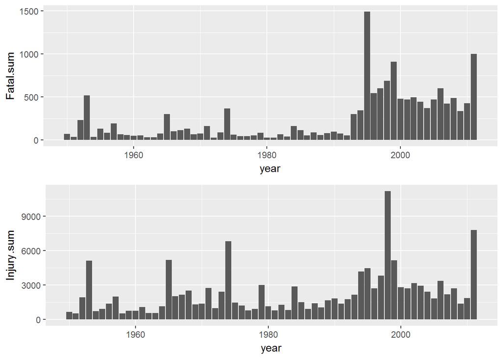

```r
library(ggplot2)
p1 <- qplot(x=year, y=Fatal.sum, data=pophealthtime, geom="col")
p2 <- qplot(x=year, y=Injury.sum, data=pophealthtime, geom="col")
multiplot(p1,p2, cols=1)
```

Next, we look at the breakdown of population health by event type, for practical purposes we look at the top 15 types by fatalities, with injuries shown. The top 3 events are tornadoes, heat, and flash flooding.

```r
spophealth[1:15,]
```

```
##                EVTYPE Fatal.sum Injury.sum
##  1:           TORNADO      5633      91346
##  2:    EXCESSIVE HEAT      1903       6525
##  3:       FLASH FLOOD       978       1777
##  4:              HEAT       937       2100
##  5:         LIGHTNING       816       5230
##  6:         TSTM WIND       504       6957
##  7:             FLOOD       470       6789
##  8:       RIP CURRENT       368        232
##  9:         HIGH WIND       248       1137
## 10:         AVALANCHE       224        170
## 11:      WINTER STORM       206       1321
## 12:      RIP CURRENTS       204        297
## 13:         HEAT WAVE       172        309
## 14:      EXTREME COLD       160        231
## 15: THUNDERSTORM WIND       133       1488
```

Last, we visualize the top economic consequences broken down into property and crops separately.

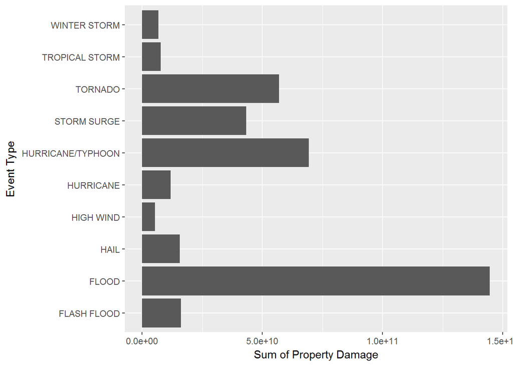

```r
plotecon <- seconcons[1:10,]
ggplot(plotecon, aes(x=EVTYPE, y=Propd.sum)) + geom_bar(stat='identity') + coord_flip() + labs(x="Event Type", y="Sum of Property Damage")
```

We observe that flooding is by far the largest cause of property damage, followed by hurricanes and tornadoes. These are all water related, which intuitively makes sense.

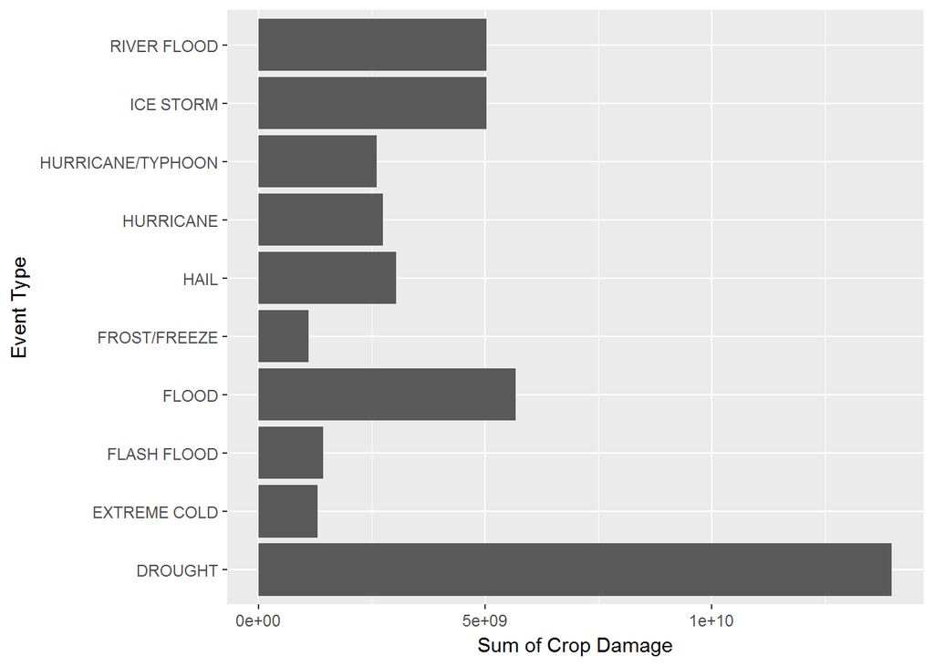

```r
plotecon <- seconcons2[1:10,]
ggplot(plotecon, aes(x=EVTYPE, y=Cropd.sum)) + geom_bar(stat='identity') + coord_flip() + labs(x="Event Type", y="Sum of Crop Damage")
```

Crops, however, are most damaged by lack of water, followed by flooding and ice related events.

### Results

Overall, intense storms have a large and significant imapct over time. The population vs. economic impacts vary based on the types of event. People and property are susceptible to different stimulus. The most economic impact on crops is due to drought (lack of water), and the most property damage comes from flooding (too much water).

### Output Considerations

The impact of the historical data collection may skew the movement of these results over time, but since the primary questions were cumulative, I feel confident in the output of this analysis.

Please do not hesitate to reach out to me if you have any questions or feedback. Mail